# logistic_regression_iris

Revanth

2024-04-18

```r
library(dplyr)
library(tidyr)
library(MASS)
```

```r
library(ggplot2)
library(cowplot)
library(caret)
library(e1071)
library(pROC)
# Load the iris dataset
data(iris)

str(iris)
```

```
## 'data.frame':    150 obs. of  5 variables:
##  $ Sepal.Length: num  5.1 4.9 4.7 4.6 5 5.4 4.6 5 4.4 4.9 ...
##  $ Sepal.Width : num  3.5 3 3.2 3.1 3.6 3.9 3.4 3.4 2.9 3.1 ...
##  $ Petal.Length: num  1.4 1.4 1.3 1.5 1.4 1.7 1.4 1.5 1.4 1.5 ...
##  $ Petal.Width : num  0.2 0.2 0.2 0.2 0.2 0.4 0.3 0.2 0.2 0.1 ...
##  $ Species     : Factor w/ 3 levels "setosa","versicolor",..: 1 1 1 1 1 1 1 1 1 1 ...
```

```r
# Split the data into training and testing sets
set.seed(42)
train_index <- createDataPartition(iris$Species, p = 0.7, list = FALSE)
train_data <- iris[train_index, ]
test_data <- iris[-train_index, ]
```

# 1. Model Deployment

## Logistic Regression Analysis

### using the glm() function to create a logistic regression model. The formula Species ~ . specifies that we want to predict the Species variable using all other variables in the dataset. The family = “binomial” argument indicates that we are performing binary logistic regression.

```r
# 1) Model Development
model <- glm(Species ~ ., data = train_data, family = "binomial")
```

# 2. Model Acceptance

### The summary(model) command provides a summary of the model, including the coefficients, their standard errors, z-values, and p-values. It helps assess the significance of each predictor variable.

```r
# 2) Model Acceptance
summary(model)
```

```
##
## Call:
## glm(formula = Species ~ ., family = "binomial", data = train_data)
##
## Coefficients:
##                Estimate Std. Error z value Pr(>|z|)
## (Intercept)      21.984 315693.606       0        1
## Sepal.Length     -3.486  83172.720       0        1
## Sepal.Width     -18.001  90955.056       0        1
## Petal.Length     15.467 117169.261       0        1
## Petal.Width       8.881 250625.620       0        1
##
## (Dispersion parameter for binomial family taken to be 1)
##
##     Null deviance: 1.3367e+02  on 104  degrees of freedom
## Residual deviance: 1.3283e-09  on 100  degrees of freedom
## AIC: 10
##
## Number of Fisher Scoring iterations: 25
```

## Insights:

### The extremely small residual deviance (1.3283e-09) compared to the null deviance (1.3367e+02) suggests that the model fits the data exceptionally well. It indicates that the predictor variables (Sepal.Length, Sepal.Width, Petal.Length, Petal.Width) collectively explain a significant amount of the variation in the response variable (Species).

### The coefficients for Sepal.Length, Sepal.Width, Petal.Length, and Petal.Width are not statistically significant, as indicated by the high p-values (all equal to 1). This suggests that these variables do not have a significant individual effect on the log-odds of the response variable.

# 3. Residual Analysis

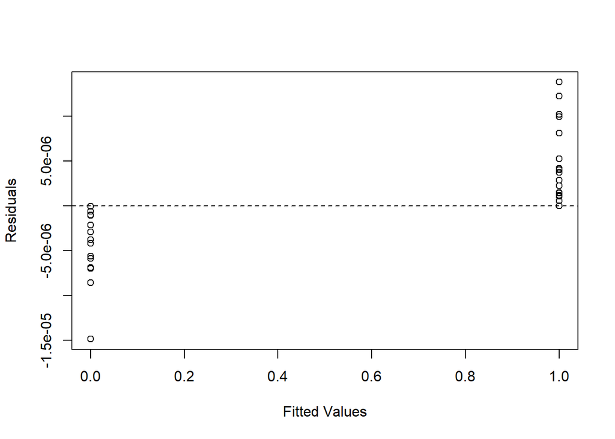

```r
# 3) Residual Analysis
residuals <- residuals(model, type = "deviance")
plot(fitted(model), residuals, xlab = "Fitted Values", ylab = "Residuals")
abline(h = 0, lty = 2)
```

# 4. Prediction

```r
# 4) Prediction
predicted_prob <- predict(model, newdata = test_data, type = "response")
predicted_class <- ifelse(predicted_prob > 0.5, "versicolor", "setosa")

predicted_prob
```

```
##            6            9           14           16           17           19
## 2.220446e-16 2.447015e-10 2.277138e-13 2.220446e-16 2.220446e-16 2.220446e-16
##           21           22           23           29           33           35
## 9.565015e-14 2.220446e-16 2.220446e-16 2.220446e-16 2.220446e-16 5.491556e-12
##           39           42           43           51           57           58
## 8.612439e-12 4.384756e-06 2.352595e-13 1.000000e+00 1.000000e+00 1.000000e+00
##           63           65           69           77           78           80
## 1.000000e+00 1.000000e+00 1.000000e+00 1.000000e+00 1.000000e+00 1.000000e+00
##           82           87           89           92           97           99
## 1.000000e+00 1.000000e+00 1.000000e+00 1.000000e+00 1.000000e+00 9.999998e-01
##          102          103          104          107          112          115
## 1.000000e+00 1.000000e+00 1.000000e+00 1.000000e+00 1.000000e+00 1.000000e+00
##          120          122          124          125          126          128
## 1.000000e+00 1.000000e+00 1.000000e+00 1.000000e+00 1.000000e+00 1.000000e+00
##          130          133          149
## 1.000000e+00 1.000000e+00 1.000000e+00
```

### The predicted class labels allow us to assess how well the model generalizes to unseen data.

# 5. Model Accuracy

```r
# 5) Model Accuracy
accuracy <- sum(predicted_class == test_data$Species) / nrow(test_data)
print(paste("Accuracy:", accuracy))
```

```
## [1] "Accuracy: 0.666666666666667"
```

### The accuracy provides an overall measure of how well the model performs in classifying the iris species.

### An accuracy of 0.666 indicates that the logistic regression model correctly predicted the outcome (the value of label) approximately 67% correctly.